# WHAT MAKES A SONG POPULAR?

### GROUP: ALLIGATOR

#### Group Members : Tanvi Reddy Kesireddy, Shreyak Mattagajasingh, Monish Bangalore Vijay Kumar, Tanisha Raaj, Joy Guo

## INTRODUCTION

Music has increasingly become a part of people’s daily lives since it is seen as a way to relax and get away from the fast moving world around us. Consequently, recent years have witnessed a rapid growth in the music industry. With newer artists making it to the Billboard’s Hot 100 and upcoming streaming platforms gaining increasing popularity, we wonder - what’s that magic formula to make a song popular? Given that any track has a variety of features, (although in varying magnitudes) maybe just the right proportion of each of these features can lead to a song becoming popular?

To understand this further, we are analyzing a Spotify dataset. Spotify is a digital music service that gives you access to millions of songs. With over 433m users, including 188m subscribers, across 183 markets, we believe the Spotify dataset would be one of the most representative samples. By the end of this project, we hope to be able to predict a track’s popularity given its features.

#### THESIS STATEMENT

Considering the various song features available, we will try to predict a track’s popularity

## BACKGROUND

#### SOURCE OF THE DATA

The dataset is obtained from Spotify directly at - https://www.aicrowd.com/challenges/spotify-million-playlist-dataset-challenge/dataset_file

The direct link to the dataset may be found at The dataset to be used may be found at :https://github.com/RutvaRajdev/Spotify-Recommendation-System/blob/master/merged_final.csv

In an attempt to learn more about the nature of playlists and thus help people by find music they love by making playlist creation more simple and accurate, Spotify sampled over 4 billion public playlists.This dataset of 1 million playlists consist of over 2 million unique tracks by nearly 300,000 artists compared across 32 variables. However, given the scope of this project, to accurately analyse our data, we will be using ony a portion of this dataset with not more than 30,000 unique tracks. The dataset includes many different measures on songs. Some of the names give an idea of what they mean such as tempo, loudness, energy. There are also very specific measures that are hard to understand if you are not that into music. For instance, acousticness, liveness, and speechiness are technical terms that we do not hear often.

More information on how this data was scraped may be found at:https://github.com/RutvaRajdev/Spotify-Recommendation-System/blob/master/DataScrape%20Notebook.ipynb

#### KEY VARIABLES

Some of the key variables in the dataset that we will be retaining are as follows:

1)track_duration_ms: Duration of the track

2)track_explicit: 0 = No explicit content, 1 = Explicit content) Categorical

4)track_popularity: The popularity of the track. The value will be between 0 and 100, with 100 being the most popular.

5)danceability: Danceability describes how suitable a track is for dancing based on a combination of musical elements including tempo, rhythm stability, beat strength, and overall regularity. A value of 0.0 is least danceable and 1.0 is most danceable.

6)energy: Energy is a measure from 0.0 to 1.0 and represents a perceptual measure of intensity and activity. Typically, energetic tracks feel fast, loud, and noisy.

7)loudness: The overall loudness of a track in decibels (dB).

8)speechiness: Speechiness detects the presence of spoken words in a track. The more exclusively speech-like the recording (e.g. talk show, audio book, poetry), the closer to 1.0 the attribute value. Values above 0.66 describe tracks that are probably made entirely of spoken words. Values between 0.33 and 0.66 describe tracks that may contain both music and speech, either in sections or layered, including such cases as rap music. Values below 0.33 most likely represent music and other non-speech-like tracks.

9)acousticness: This value describes how acoustic a song is. A maximum score of 1.0 means the song is most likely to be an acoustic one with a minimum score of 0 meaning the song is least likely to be an acoustic one.

10)instrumentalness: Predicts whether a track contains no vocals. “Ooh” and “aah” sounds are treated as instrumental in this context. Rap or spoken word tracks are clearly “vocal”. The closer the instrumentalness value is to 1.0, the greater likelihood the track contains no vocal content.

11)liveness: This value describes the probability that the song was recorded with a live audience ( Ranges from 0 to 1)

12)valence: A measure from 0.0 to 1.0 describing the musical positiveness conveyed by a track.

13)tempo: The overall estimated tempo of a track in beats per minute (BPM).

14)artist_popularity: The popularity of the artist. The value will be between 0 and 100, with 100 being the most popular.

15)artist_genre1 : The primary genre used to classify the album.

We intend to analyse these features and the strength of the correlation between them to understand which of the features play the most important role in determining the track’s popularity. To analyse the same further, we will also use a multiple regression model (with track features as explanatory variables) to predict the outcome of track popularity. (response variable)

Nevertheless, this dataset is not without its faults.We must keep in mind that streaming platforms such as Spotify are more popular among younger generations and thus may not reflect tastes and preferences of the older populations. We see that more later decades have more songs and this may skew the data to reflect more recent trends disproportionately.

```
## # A tibble: 8 × 2
##   period    song_count
##   <chr>          <int>
## 1 1941-1950          3
## 2 1951-1960         31
## 3 1961-1970        400
## 4 1971-1980        493
## 5 1981-1990        565
## 6 1991-2000       1670
## 7 2001-2010       5661
## 8 2011-2020      17669
```

## EXPLORATORY DATA ANALYSIS

#### DATA TIDYING

To make our analysis more accurate, we will first tidy the dataset to only retain relevant rows and columns.

-All values in the album_release_date column that are not in the appropriate date format are dropped

-Rows with missing values are also dropped.

-Duplicate rows in the dataset which is removed.

-Only relevant columns are selected

The resulting dataframe will be used for the further analysis

```
## # A tibble: 10 × 15
##    track_name      track_popularity track_duration_… track_explicit danceability
##    <chr>                      <dbl>            <dbl> <lgl>                 <dbl>
##  1 Avril 14th                    68           125520 FALSE                0.558
##  2 His Theme (fea…               26            88700 FALSE                0.548
##  3 Changing You A…               15           134096 FALSE                0.427
##  4 공주를 사랑한 …               26           171834 FALSE                0.46
##  5 Wildlife Analy…               46            75626 FALSE                0.0936
##  6 Relaxing Music                28           120280 FALSE                0.608
##  7 Piano Sonata N…               17           199634 FALSE                0.376
##  8 Home                          11           219906 FALSE                0.388
##  9 Adam's Song                   23           251053 FALSE                0.622
## 10 I Miss You                    24           218973 FALSE                0.589
## # … with 10 more variables: energy <dbl>, loudness <dbl>, speechiness <dbl>,
## #   acousticness <dbl>, instrumentalness <dbl>, liveness <dbl>, valence <dbl>,
## #   tempo <dbl>, artist_popularity <dbl>, artist_genre1 <chr>
```

## ANALYSIS

To analyse what makes a song popular, it may also be helpful to analyse what makes one genre more popular than the others. The following graph plots the mean of each track feature for various genres. Since the data set has more than 100 genres and is extensive, we will use the top 10 most popular genres to analyse this trend. Genre popularity is calculated as sum of track popularities since tracks belong to a particular genre and genre popularity depends on track popularity.

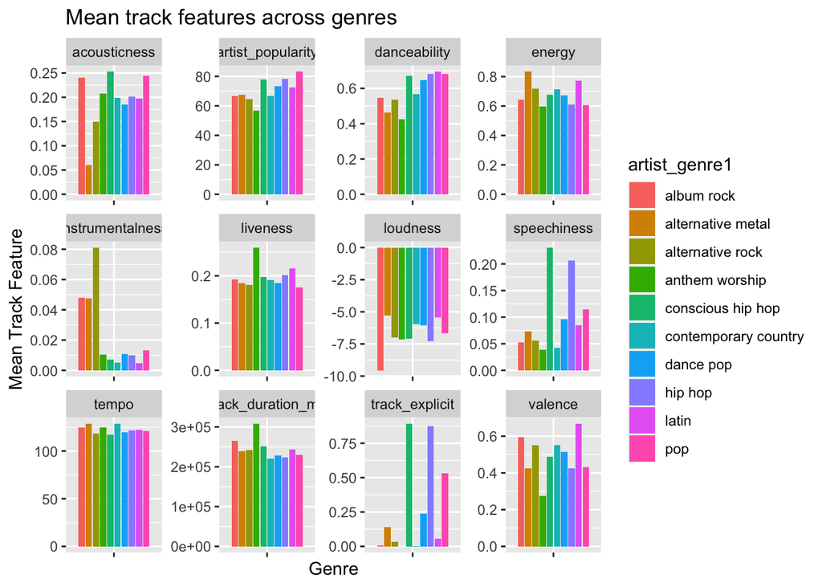

We do not see any striking trend that might help explain why tracks of a particular genre are more popular than the other.

To further analyse the strength of the linear relationship between track feature and track popularity, we may find the coefficient of correlation between each of the features.

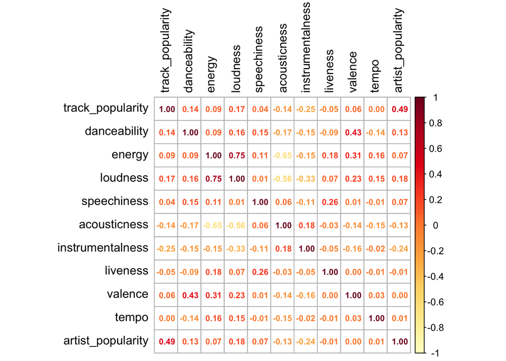

Coefficient of correlation measures the strength of the linear relationship between two quantitative variables. The highest positive correlation between two quantitative variables is 1 and the lowest positive correlation between two quantitative variables is -1.

Unfortunately, observe that no particular feature has a strong relation with track popularity. Hence, this plot only helps us conclude the following:

- Acousticness, instrumentalness and liveness have a negatively correlation with track popularity.
- Danceability, energy, loudness, speechiness, artist_poularity and valence have a positive correlation with track popularity.
- Tempo has no correlation with track popularity.
- Track popularity is most strongly related to artist popularity.

While correlation measures only the strength and direction of the linear relationship between two quantitative variables, we can use a regression model to describe how a response variable y changes as an explanatory variable x. In this case, we can see how the changes in track popularity are affected by changes in other features. Since we are using changes in multiple features to predict changes in track popularity, we can use a multiple regression model to attempt to predict popularity. In the following model, we will use track popularity as the response variable and danceability, energy, loudness, speechiness, acousticness, instrumentalness, liveness, valence, tempo, artist_popularity and track duration as the covariates.

The following is a summary table of the multiple regression model:

```
##
## Call:
## lm(formula = track_popularity ~ danceability + energy + loudness +
##     speechiness + acousticness + instrumentalness + liveness +
##     valence + tempo + artist_popularity + track_duration_ms +
##     track_explicit, data = final_df)
##
## Residuals:
##     Min      1Q  Median      3Q     Max
## -61.009  -8.840   2.277  11.476  44.280
##
## Coefficients:
##                      Estimate Std. Error t value Pr(>|t|)
## (Intercept)         8.875e+00  1.684e+00   5.271 1.38e-07 ***
## danceability        2.614e+00  1.027e+00   2.544    0.011 *
## energy             -5.664e-01  1.188e+00  -0.477    0.634
## loudness            9.470e-02  6.119e-02   1.548    0.122
## speechiness        -1.583e+00  1.322e+00  -1.197    0.231
## acousticness       -2.697e+00  6.511e-01  -4.143 3.45e-05 ***
## instrumentalness   -1.005e+01  6.697e-01 -15.012  < 2e-16 ***
## liveness           -5.820e+00  8.395e-01  -6.933 4.29e-12 ***
## valence             2.695e+00  6.812e-01   3.957 7.63e-05 ***
## tempo              -5.160e-03  4.817e-03  -1.071    0.284
## artist_popularity   5.259e-01  9.192e-03  57.213  < 2e-16 ***
## track_duration_ms   1.047e-05  1.866e-06   5.615 2.01e-08 ***
## track_explicitTRUE  2.171e+00  4.145e-01   5.238 1.65e-07 ***
## ---
## Signif. codes:  0 '***' 0.001 '**' 0.01 '*' 0.05 '.' 0.1 ' ' 1
##
## Residual standard error: 16 on 14170 degrees of freedom
## Multiple R-squared:  0.2696, Adjusted R-squared:  0.269
## F-statistic: 435.8 on 12 and 14170 DF,  p-value: < 2.2e-16
```

1. The following plot shows the relationship between track_popularity and the residual values from our regression model.

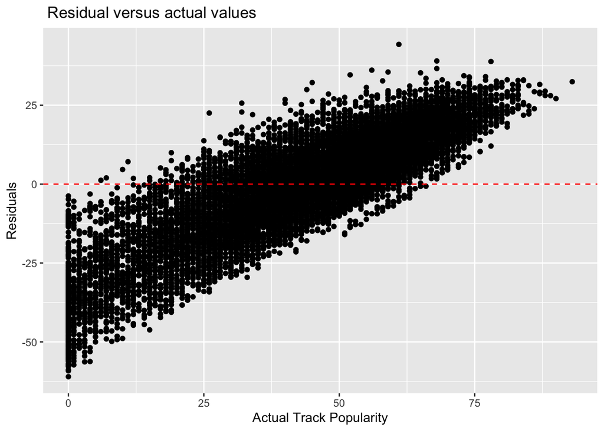

2. The following graph describes the relationship between sample quantiles and theoretical quantiles.

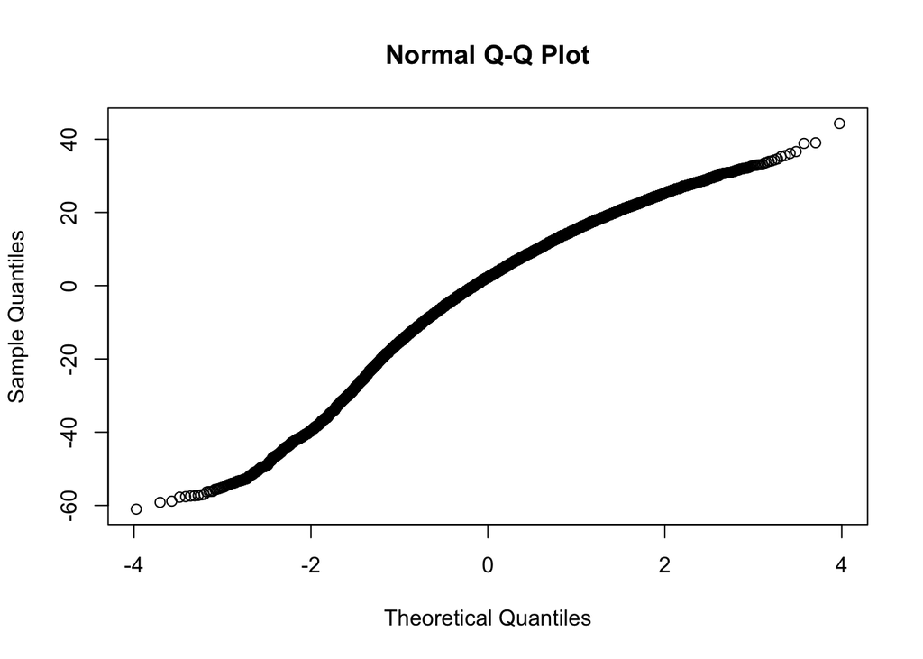

An accurate multiple regression model would have a normal residual distribution. To check for a normal distribution in the residuals, we can plot theoretical quantiles against sample quantiles. We fail to observe a straight line in the aforementioned plot and can thus conclude that the residuals are not normally distributed.

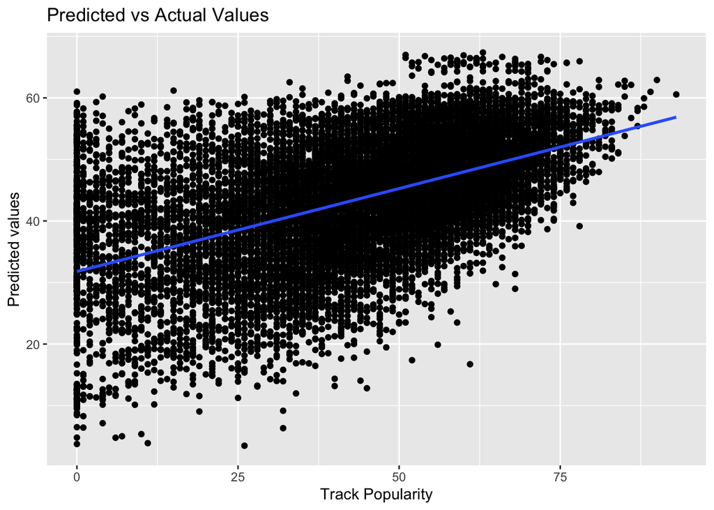

## DISCUSSION

#### POTENTIAL SHORTCOMINGS

- The data from the past do not contain as many songs as of the data from the current songs. Thus the data is a little skewed.
- The data is from a Spotify data set so it does not actually contain all songs as many songs do not release on Spotify.
- The features listed in this dataset are not exhaustive - i.e they are not the only features that a song is comprised of. Perhaps, adding in all the other rarely discussed features of a song such as pitch and rhythm may be helpful in making our model more accurate.
- Some of the features mentioned such as speechiness is vague. More targeted analysis of songs containing specific words might greatly aid predicting track popularity better.

#### REFLECTION FOR FUTURE WORK

In general, songs become more popular when we as an audience resonate with it. Track popularity is reflective of the extent to which the audience reciprocate the song and this is an extremely qualitative quantity to measure.Moreover, though an artist in a creative field may experience a huge success once, it is not guaranteed that all his other works would be as successful. This is proof of the fact that popularity of any work may not be well predicted in advance even if it is produced by one of the most reputed artists. We as a team still continue to be curious to understand what makes a song what it is. Perhaps, other models ( not necessarily linear) would do a better job at explaining this?

Further, linear regression is not the only method to analyse the popularity in this dataset.

Further questions involving popularity could involve more in depth measurement of confidence intervals of several genres.

This could certainly be an area of interest for future work.

Therefore, the features that appears in the data set is not sufficient to determine track popularity. Thus, the features of songs can only be a potential measurement of its popularity.

**References**

1. https://www.aicrowd.com/challenges/spotify-million-playlist-dataset-challenge/dataset_file
2. :https://github.com/RutvaRajdev/Spotify-Recommendation-System/blob/master/merged_final.csv
3. https://statisticsbyjim.com/regression/interpret-adjusted-r-squared-predicted-r-squared-regression/
4. https://towardsdatascience.com/understanding-linear-regression-output-in-r-7a9cbda948b3